Consider a binary classification task where the features are high-dimensional. Use `hw5prob1\hw5prob1_train.txt` as data to train a kernel SVM, and test on `hw5prob1_test.txt` to obtain the prediction accuracy. In each of the text files, the last column is the response variable.

1. Fit a SVM procedure with quadratic kernel and report the test misclassification rate. Use the `tune` function to pick the best value of `cost`. Try different values of `gamme`, e.g. 0.1, 1, 10.

I tried using the `tune` function, but it ran for nearly 24 hours and did not complete. I tried running it with simpler values for gamma and cost on numerous occasions and it never completed within 2hrs. Instead, I used default SVM settings in order to finish the assignment.

```
The test misclassification rate is 0.99 for the polynomial svm.
```

```r
set.seed(1)
colnames(train_set)[ncol(train_set)]
```

```
## [1] "X.1"
```

```r
#tune_poly <- tune(svm, X.1 ~ ., data = train_set, kernel = "polynomial", degree=2, scale = FALSE,
#                     ranges = list(gamma = c(0.1, 1, 10), cost = c(0.1, 1, 10)))

svmfit_poly <- svm(X.1 ~ ., data=train_set, kernel="polynomial", degree=2, scale = FALSE)

summary(svmfit_poly)
```

```
##
## Call:
## svm(formula = X.1 ~ ., data = train_set, kernel = "polynomial",
##     degree = 2, scale = FALSE)
##
##
## Parameters:
##    SVM-Type:  eps-regression
##  SVM-Kernel:  polynomial
##        cost:  1
##      degree:  2
##       gamma:  0.008130081
##      coef.0:  0
##     epsilon:  0.1
##
##
## Number of Support Vectors:  4347
```

```r
plot(svmfit_poly, train_set)

svmfit_poly2=svm(X.1 ~., data=test_set, kernel="polynomial", degree=2, decision.values =T, scale = FALSE)
#fitted_poly=attributes(predict(svmfit_poly2,test_set, decision.values=TRUE))$decision.values
#PredTable<-table(test_set$X.1, as.vector(fitted_poly))
#TestError<-(1-(sum(diag(PredTable))/sum(PredTable)))
#TestError # 0.9998785

ypred<-predict(svmfit_poly2, test_set)
ypred<-as.vector(ypred)
testy<-as.vector(test_set$X.1)
PredTable<-table(predict=ypred, truth=testy)
TestError<-1-sum(diag(PredTable))/sum(PredTable)
TestError # 0.9998785
```

```
## [1] 0.9998785
```

2. Fit a SVM procedure with radial kernel and report the test misclassification rate. Use the `tune` function to pick the best value of `cost`. Try different values of `gamme`, e.g. 0.01, 0.1, 1.

   The test misclassification rate is 0.99 for the radial svm.

```r
set.seed(1)
colnames(train_set)[ncol(train_set)]
```

```
## [1] "X.1"
```

```r
#tune_radi <- tune(svm, X.1 ~ ., data = train_set, kernel = "radial", scale = FALSE,
#                     ranges = list(gamma = c(0.1, 1, 10), cost = c(0.1, 1, 10)))
svmfit_radi <- svm(X.1 ~ ., data =train_set, kernel="radial", scale = FALSE)

summary(svmfit_radi)
```

```
##
## Call:
## svm(formula = X.1 ~ ., data = train_set, kernel = "radial", scale = FALSE)
##
##
## Parameters:
##    SVM-Type:  eps-regression
##  SVM-Kernel:  radial
##        cost:  1
##       gamma:  0.008130081
##     epsilon:  0.1
##
##
## Number of Support Vectors:  4821
```

```r
plot(svmfit_radi, train_set)

svmfit_radi2=svm(X.1 ~., data=test_set, kernel="radial", decision.values =T, scale = FALSE)
ypred<-predict(svmfit_radi2, test_set)
ypred<-as.vector(ypred)
testy<-as.vector(test_set$X.1)
PredTable<-table(predict=ypred, truth=testy)
TestError<-1-sum(diag(PredTable))/sum(PredTable)
TestError # 0.9998785
```

```
## [1] 0.9998785
```

3. Compare the result of quadratic kernel and radial kernel by constructing ROC curves of the best quadratic kernel model and the best radial basis kernel model above.

The polynomial had a slightly better ROC curve, but they were both nearly indistinguishable.

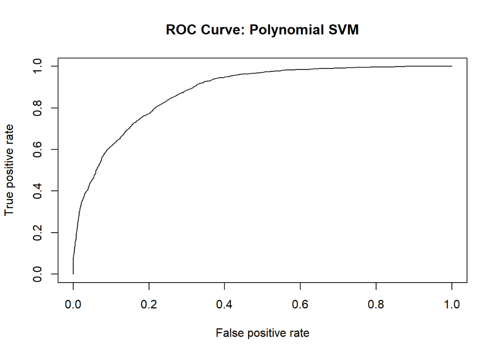

```r
svmfit_poly2=svm(X.1 ~., data=train_set, kernel="polynomial", degree=2, decision.values =T, scale = FALSE)
fitted_poly=attributes(predict(svmfit_poly2,train_set, decision.values=TRUE))$decision.values
pred<-prediction(as.vector(fitted_poly), train_set$X.1)
AUCPlot_poly<-performance(pred, measure = "tpr", x.measure = "fpr")
ROCR::plot(AUCPlot_poly, main="ROC Curve: Polynomial SVM")
```

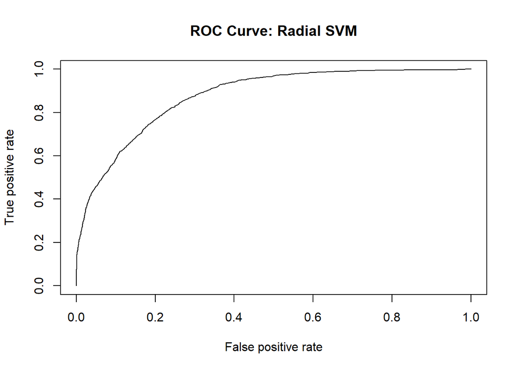

```r
svmfit_radi2=svm(X.1 ~., data=train_set, kernel="radial", decision.values =T, scale = FALSE)
fitted_radi=attributes(predict(svmfit_radi2,train_set, decision.values=TRUE))$decision.values
pred<-prediction(as.vector(fitted_radi), train_set$X.1)
AUCPlot_radi<-performance(pred, measure = "tpr", x.measure = "fpr")
ROCR::plot(AUCPlot_radi, main="ROC Curve: Radial SVM")
```